# Future scenarios in the making, in historical Prague

Author

Kelsey Roberts

Published

August 1, 2023

In June, several members of FishMIP attended and presented at the [cross-sectoral ISIMIP-PROCLIAS workshop in Prague,](https://www.isimip.org/outcomes/upcoming-cross-sectoral-isimip-proclias-workshop-2023/) Czech Republic. During this meeting, a wide variety of plenary sessions and parallel meetings took place and individual sectors (e.g., forest, water, fisheries, agriculture, permafrost, health, lakes) provided updates on recent simulation results as well as initiatives to properly address representative key risks highlighted in the IPCC report. Myself, Julia Blanchard, Camilla Novaglio and Tyler Eddy participated in an afternoon panel session to present recent Fish-MIP results to the broader ISIMIP community on pathways to reduce uncertainties in the marine ecosystem models and mismatches in global vs. regional model climate projections, respectively.

During the closed sessions, the FishMIP community used the in-person, dedicated time to discuss the next protocol centered around the oceanic system pathways (OSPs) and how they will soon be integrated into the global models. The OSPs, [developed by Olivier Maury](https://doi.org/10.1016/j.gloenvcha.2017.06.007), are extensions of the [shared socioeconomic pathways (SSPs)](https://www.carbonbrief.org/explainer-how-shared-socioeconomic-pathways-explore-future-climate-change/) and representative concentration pathways (RCPs) with a total of five unique scenarios. Similar to the SSPs, the OSPs take into account climate change effects but extend the storyline to incorporate important drivers in the fishery world, such as demand in terms of human population sizes, gross domestic products, fisheries fleet dynamics, and fisheries management rules. The logistics of harmonizing the OSPs to the global FishMIP models were mapped out alongside target timelines for future meetings. In their downtime, the in-person FishMIP team explored the historic city of Prague and frequented restaurants with the best views of the beautiful Charles Bridge.

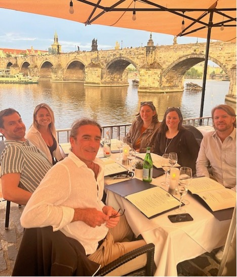

The in-person FishMIP team in the historic city of Prague, with the Charles Bridge in the background.